# 9.1 - Introducción al análisis de datos temporales

26 de marzo de 2020

## Datos temporales

## Introducción

- Desde finales de 1970 se ha popularizado el análisis de **datos con dependencias temporales**. Sin embargo, se han desarrollado métodos y herramientas de forma *independiente* en distintas áreas, sin ninguan cohesión.
- Solo en las últimas dos décadas se está produciendo un efecto de *trasvase* de técnicas entre diferentes áreas (economía, demografía, medicina, sociología, ingeniería, etc.).
- Es importante extremar las precauciones para comprender los requisitos y supuestos que se requieren para aplicar cada técnica, pues de otro modo corremos enormes riesgos a la hora de realizar **predicción** o **inferencia**.
  - Muchos **métodos estadísticos habituales no pueden aplicarse** directamente a datos con correlación temporal entre sí.
- Curiosamente, en la década de 1960 y 1970 había serias dudas en muchas áreas científicas sobre la posibilidad de desarrollar modelos para medir y comprender el cambio en individuos o grupos, a lo largo del tiempo.
- Entre 1957 y 1960 aparecieron las primeras técnicas de suavizado exponencial. En 1970 Box y Jenkins publican su influyente libro *“Time series analysis: Forecasting and control”*, estableciendo las bases para uno de los métodos más populares de **análisis de series temporales**.

## Introducción: datos temporales

- Los **datos temporales** son aquellos que ofrecen valores **obtenidos a lo largo del tiempo**. Es decir, necesitamos un campo (columna, si es una tabla de datos) con información sobre el instante en que fue tomado el dato.
- En estadística matemática y, especialmente, en economía (econometría) se suele usar el término equivalente **datos de panel**.

| Id | Tiempo | var1 | var2 | var3 |
| --- | --- | --- | --- | --- |
| 1 | 2014 | campeón | 30 | 10 |
| 1 | 2015 | cuartos | 19 | 21 |
| 1 | 2016 | campeón | 31 | 15 |
| 2 | 2014 | cuartos | 15 | 16 |
| 2 | 2015 | semifinal | 21 | 20 |
| 2 | 2016 | grupos | 12 | 16 |

## Introducción: datos de panel

- Decimos que un panel de datos es **balanceado** cuando tenemos el mismo número de observaciones para cada individuo o caso, en todos los puntos temporales considerados.
- Si tenemos diferente número de muestras temporales para cada caso (por ejemplo, nos faltan datos para ciertos años, meses, etc.) entonces hablamos de un panel de datos *no balanceado*.
- En muchas ocasiones los datos de panel se organizan de la forma en la que hemos visto en la tabla anterior. Ese formato se denomina **long format**.
- Otro formato alternativo es poner cada caso o individuo en una sola fila, e ir añadiendo columnas etiquetadas con el nombre de la variable y la fecha o instante temporal en que se tomó ese valor. Este otro formato se denomina **wide format**.
- [Cómo transformar datos entre long y wide format](http://www.cookbook-r.com/Manipulating_data/Converting_data_between_wide_and_long_format/) (RCookbook).

## Datos longitudinales y series temporales

- En ocasiones, se usa también el término **datos longitudinales** para referirse a datos de panel (con dependencias temporales). Además, tenemos otras series de datos temporales llamadas **series temporales**.
- Hay una diferencia entre *datos longitudinales* y *series temporales* [Wei 2019].
- El término *datos longitudinales* designa a conjuntos de datos que contienen valores para una muestra aleatoria de individuos o casos, registrados en diferentes instantes de tiempo. Para cada caso, tenemos **pocos valores** en el tiempo.
  - Por ejemplo, un estudio sobre la evolución de resultados académicos de alumnos en un colegio; datos sobre pacientes con problemas cardivasculares, tomados cada 6 meses para cada paciente, etc.
  - El término *datos longitudinales* proviene de áreas como bioestadística, ciencias de la salud o estudios sociológicos y políticos. A veces, también se usa el término **medidas repetidas**.

- Una **serie temporal** designa una única serie de valores (para un solo caso o individuo), medidos a lo largo del tiempo. Normalmente, tenemos **muchos valores** registrados para cada caso (la serie es “larga”, comparada con datos longitudinales).

## Datos longitudinales y series temporales

- Hay diferencias en los **objetivos y métodos de trabajo** para cada tipo de análisis.
- El objetivo en **datos longitudinales** es analizar diferencias entre individuos o grupos de individuos (o casos), controlando la *dependencia temporal* entre los datos recogidos.
  - Detectar diferencias entre grupos, controlando la dependencia temporal de los datos para un mismo individuo en diferentes instantes.
  - Por tanto, el principal objetivo en esos estudios suele ser **inferencia**.

- El objetivo en **series temporales** es descubrir patrones y estructuras en la serie de datos (aprovechando sus propiedades estocásticas), para proponer un modelo de **predicción**, que anticipe el valor de futuros datos.

- En este tema nos ocuparemos de **series temporales**, estudiando diferentes tipos de modelos que podemos aplicar para estudiar la serie de valores.

## Datos transversales y series temporales

- Entonces, ¿qué aplicación tienen las técnicas estadísticas vistas hasta ahora?
- Los datos que hemos visto hasta ahora (ignorando dependencias temporales) se denominan en este contexto **datos transversales**.
  - **Datos transversales**: Son datos sobre una o varias variables, medidos para varios individuos pero todos ellos obtenidos en el mismo punto temporal. En el panel de datos, correspondería a los datos por filas para varios individuos en el mismo instante de tiempo.
  - Los datos transversales **no permiten estudiar cambios en casos o individuos**, como tampoco permiten realizar **predicción para valores en el futuro** (*forecasting*, diferente de *prediction*).
  - **Series temporales**: Una serie temporal se construye como resultado de observar los valores de una variable a lo largo del tiempo, normalmente en intervalos regulares (aunque no es obligatorio, y entonces hablamos de *unevenly or irregularly spaced time series*). En el panel de datos, correspondería a los datos de una sola variable (columna), medidos para un único individuo o caso.
    - O también hablamos de *time-structured data* y *time-unstructured data* [Singer & Willett 2003].

## Herramientas para análisis de datos temporales

- Dependiendo del tipo de pregunta que nos hagamos, podemos elegir entre una amplia variedad de técnicas y herramientas para analizar datos temporales [Singer & Willett, 2003].
  - Comparación de medias entre dos medidas del mismo caso o individuo: *paired t-test*.
  - Cambios intra-individuales y entre individuos/grupos: *mixed effect models* o *modelos multinivel*.
    - Nivel 1: Cambios para **un mismo individuo** o caso en el tiempo.
    - Nivel 2: Cambios de las **diferencias entre individuos** o casos en el tiempo.
  - Análisis de tiempo hasta que sucede un evento: **análisis de superviviencia**.
  - Análisis de secuencias de eventos: *modelos multiestado* (cadenas de Markov), *análisis de secuencia o trayectoria*.

## Herramientas para análisis de datos temporales

Predicción de valores futuros: **análisis de series temporales**.

- Descomposición de estacionalidad y tendencia.
- Modelos autorregresivos (AR, MA, ARMA, ARIMA, SARIMA, SARUMA, SARIMAX, etc.).
  - Relación entre sistemas dinámicos: **funciones de transferencia**.
  - Factores que influyen en la serie: **análisis de intervención**.
- Modelos para alta volatilidad (ARCH, GARCH).
- Suavizado exponencial (*exponential smoothing*).
- **Análisis multivariante de series temporales** (en cada instante un vector, no un único valor; e.g. VARMA).
- Análisis en el dominio de la frecuencia (*spectral analysis*, transformada de Fourier).
- **Control de procesos** (ingeniería, producción).

Nosotros nos vamos a centrar en los dos primeros tipos.

- Descomposición de estacionalidad y tendencia (STL).
- Modelos autorregresivos integrados de medias móviles (ARIMA).

## Representación de datos temporales

## Datos temporales en R

- Para la representación de datos temporales en R, normalmente distinguimos entre dos posibles situaciones:
  - Análisis de **datos de panel**: Normalmente se representan mediante un data.frame, siguiendo el formato **long**. A pesar de ello, ciertas herramientas (por ejemplo, algunos tipos de análisis de secuencia) exigen encontrar los datos en formato *wide*.
  - Análisis de **series temporales**: Se suelen emplear objetos (clases) en R especializados para la representación de series temporales.
    - `ts` ofrece la versión más básica.
    - `zoo` ofrece soporte para series con espacio regular o irregular, además de soportar también datos faltantes (rupturas en la serie de valores). Intenta ser lo más consistente posible con las funciones del paquete básico `ts`.
    - `xts` es un tercer paquete que intenta proporcionar una interfaz uniforme para trabajar con datos de series temporales en R.
    - `tsibble` es un nuevo paquete del grupo de Rob Hyndman, para representación y análisis de series temporales dentro del ecosistema *tidyverse*: https://tsibble.tidyverts.org/.
    - `tidyquant` es otra alternativa para análisis de series temporales, integrada en *tidyverse*, más enfocado a datos financieros: [Introducción a `tidyquant`](https://cran.r-project.org/web/packages/tidyquant/vignettes/TQ00-introduction-to-tidyquant.html).

## Ejemplo: conversión *long* a *wide* y viceversa

- Función `tidyr::gather()`: https://tidyr.tidyverse.org/reference/gather.html.
- Función `tidyr::spread()`: https://tidyr.tidyverse.org/reference/spread.html.
- **Nuevas funciones para pivotar**: https://tidyr.tidyverse.org/dev/articles/pivot.html.
  - Sustituyen a las antiguas funciones `gather()` y `spread()` del paquete `tidyr`.
  - Incluyen funcionalidades más flexibles y una interfaz teóricamente más intuitiva para transformar los datos entre ambos formatos.

## Series temporales en R: `xts`

- [Ventajas de la clase `xts`](https://cran.r-project.org/web/packages/xts/vignettes/xts.pdf).
  - Existen diferentes clases en R que resuelven varios problemas relacionados con la representación y tratamiento de series temporales.
  - `tseries::irts`, `Rmetrics::timeSeries`, paquetes `its` y `zoo`.
  - Esto obliga a constantes cambios de clase (*casting* de variables), en los que se van perdiendo atributos en cada cambio.
  - Además de proporcionar soporte para no perder los atributos propios de cada clase original, `xts` permite añadir nuevos atributos a cada serie.
- Basado en la clase `zoo`.
- Formatos de fecha soportados: `POSIXct`, `chron`, `yearmon`, `yearqtr` o `timeDate`.
- Desventajas: `xts` no está integrado con el ecosistema de herramientas y paquetes de *tidyverse* (nuevo paquetes como `tsibble` si lo están).

## Ejemplo `xts` con matrices

```r
require(xts)
data(sample_matrix)
str(sample_matrix)
```

```
##  num [1:180, 1:4] 50 50.2 50.4 50.4 50.2 ...
##  - attr(*, "dimnames")=List of 2
##   ..$ : chr [1:180] "2007-01-02" "2007-01-03" "2007-01-04" "2007-01-05" ...
##   ..$ : chr [1:4] "Open" "High" "Low" "Close"
```

```r
# Si no se indica formato usa `POSIXct` por defecto
matrix_xts <- as.xts(sample_matrix, dateFormat='Date')
str(matrix_xts)
```

```
## An 'xts' object on 2007-01-02/2007-06-30 containing:
##   Data: num [1:180, 1:4] 50 50.2 50.4 50.4 50.2 ...
##  - attr(*, "dimnames")=List of 2
##   ..$ : NULL
##   ..$ : chr [1:4] "Open" "High" "Low" "Close"
##   Indexed by objects of class: [Date] TZ: UTC
##   xts Attributes:
##  NULL
```

## Subsetting con `xts`

- Un aspecto muy potente de `xts` es que permite indexar datos usando strings con información temporal, de forma intuitiva.

```r
head(matrix_xts['2007-03'])
```

```
##                Open     High      Low    Close
## 2007-03-01 50.81620 50.81620 50.56451 50.57075
## 2007-03-02 50.60980 50.72061 50.50808 50.61559
## 2007-03-03 50.73241 50.73241 50.40929 50.41033
## 2007-03-04 50.39273 50.40881 50.24922 50.32636
## 2007-03-05 50.26501 50.34050 50.26501 50.29567
## 2007-03-06 50.27464 50.32019 50.16380 50.16380
```

```r
# Desde el comienzo hasta el 5 de enero de 2007
# matrix_xts['/2007-01-05']
# Desde el 25 de junio de 2007 hasta el final
# matrix_xts['2007-06-25/']
# Selecciona primeras 2 semanas de datos
# first(matrix_xts, '2 week')
# Selecciona los últimos 3 días de las primeras 2 semanas
# first(last(matrix_xts, '2 week'), '3 days')
```

## Representación gráfica `xts`

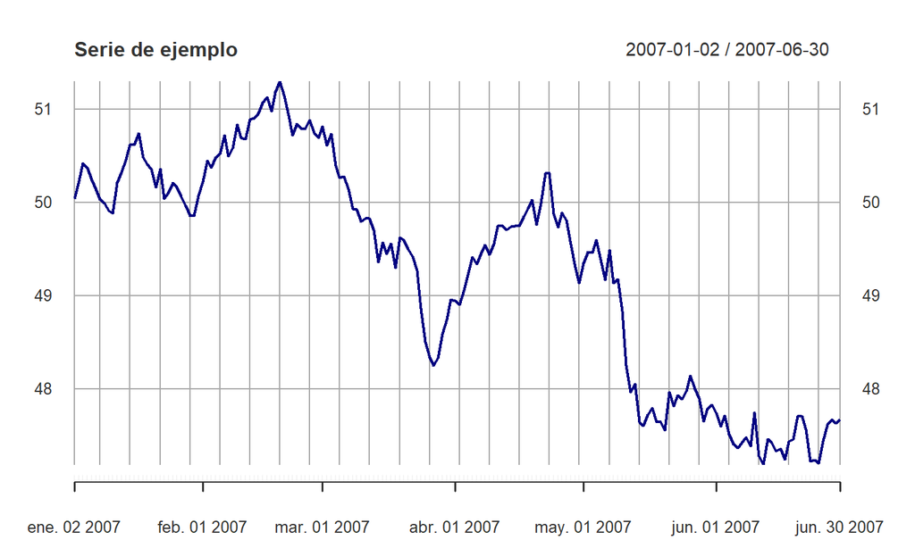

```r
plot(matrix_xts[,1], major.ticks = 'months', minor.ticks = FALSE, col='navy',
     main='Serie de ejemplo')
```

## Vuelta a la clase original

- Usamos `xts::reclass`.
- Internamente, recuerda la clase original del objeto (si la hubiese) y preserva de forma inteligente todos los atributos especiales que pudiera tener.

```r
str(reclass(as.xts(sample_matrix)['2007-05']))
```

```
## An 'xts' object on 2007-05-01/2007-05-31 containing:
##   Data: num [1:31, 1:4] 49.3 49.5 49.5 49.6 49.4 ...
##  - attr(*, "dimnames")=List of 2
##   ..$ : NULL
##   ..$ : chr [1:4] "Open" "High" "Low" "Close"
##   Indexed by objects of class: [POSIXct,POSIXt] TZ:
##   xts Attributes:
##  NULL
```

## Periodicidad de datos

```r
periodicity(matrix_xts)
```

```
## Daily periodicity from 2007-01-02 to 2007-06-30
```

```r
# Cambiar a periodicidad mensual
montly_matrix_xts = to.period(matrix_xts, 'months')
periodicity(montly_matrix_xts)
```

```
## Monthly periodicity from 2007-01-31 to 2007-06-30
```

```r
to.monthly(matrix_xts)  # Con etiquetas adecuadas
```

```
##           matrix_xts.Open matrix_xts.High matrix_xts.Low matrix_xts.Close
## ene. 2007        50.03978        50.77336       49.76308         50.22578
## feb. 2007        50.22448        51.32342       50.19101         50.77091
## mar. 2007        50.81620        50.81620       48.23648         48.97490
## abr. 2007        48.94407        50.33781       48.80962         49.33974
## may. 2007        49.34572        49.69097       47.51796         47.73780
## jun. 2007        47.74432        47.94127       47.09144         47.76719
```

## Aplicación de funciones por periodos

```r
# period.apply(matrix_xts[,4], INDEX=endopoints(matrix_xts, on='months'), FUN=min)
# Equivalente, más claro
# apply.monthly(matrix_xts[,4], FUN=min)
# Versión optimizada para muchos datos
period.max(matrix_xts[,4], endpoints(matrix_xts, on='months'))
```

```
##                [,1]
## 2007-01-31 50.67835
## 2007-02-28 51.17899
## 2007-03-31 50.61559
## 2007-04-30 50.32556
## 2007-05-31 49.58677
## 2007-06-30 47.76719
```

```r
# Además: apply.daily, apply.weekly, apply.quarterly, apply.yearly
```

## Series temporales en *tidyverse*

## Series temporales y *tidy data*

- El conjunto de paquetes que conforman `tidyverse` se ha vuelto muy popular en R.
- Implementan los principios de **tidy data**, introducidos por H. Wickham.
- Implementan una **gramática de datos**, similar a la de otros lenguajes de programación (e.g. `Pandas` en Python) para procesado y análisis de datos estructurados.
- Incorpora los **principios de diseño** de **bases de datos relacionales** para tratar con tablas de datos.
- Como consecuencia, tiene sentido que aparezcan nuevos paquetes que integren soporte para procesado y análisis de series temporales en este entorno:
  - `tsibble` es un paquete creado por el equipo de Rob Hyndman (autor, entre otros, del paquete `forecast`).
  - https://pkg.earo.me/tsibble/.
  - `tidyquant` es un paquete creado por Matt Dancho, para dar soporte al análisis de series temporales económicas, dentro del ecosistema de paquetes del `tidyverse`.
  - [Vignette: Introduction to tidyquant](https://cran.r-project.org/web/packages/tidyquant/vignettes/TQ00-introduction-to-tidyquant.html).

## El paquete *tsibble*

## Introducción a `tsibble`

- Todavía está en fase de desarrollo (versión 0.8.6 en este momento), pero evoluciona muy rápidamente.
- Se ha creado un subconjunto de paquetes llamado `tidyverts`, que integra varias herramientas junto a `tsibble` para análisis de datos: https://tidyverts.org/.
- `tsibble`tiliza la clase `tbl_ts` para representar *tidy data* en contextos de análisis temporales. El objeto se construye a partir de una `tibble`, y consta de:
  - Un **índice temporal** (una columna de nuestra tabla de datos).
  - Una clave para cada entrada. Puede constar de una o varias columnas, para identificar casos individuales.
  - El resto de variables (columnas) que miden valores en cada instante que indica el índice temporal.
- Incorpora diversos avances, como por ejemplo soporte para series temporales jerárquicas y agrupadas, esto es, agrupaciones de series temporales relacionadas entre sí (por ejemplo, por género, geografía o tipo de producto).
- Las series temporales jerárquicas se pueden analizar con el paquete `hts` de los mismos autores, pero sin soporte para tidy data.

## Creación de objetos `tsibble`

- La función `tsibble()` crea un objeto de este tipo.
- La función `as_tsibble()` convierte objetos de otro tipo en un `tsibble`.
  - La conversión es automática para objetos `ts`, `xts` o `hts`.
  - Si es un `data.frame` o una `tibble`, necesitamos indicar las columnas que actuarán como índice y clave.
- Veamos un ejemplo con datos meteorológicos del paquete nycflights13.

```r
weather <- nycflights13::weather %>%
  select(origin, time_hour, temp, humid, precip)
head(weather, 4)
```

```
## # A tibble: 4 x 5
##   origin time_hour            temp humid precip
##   <chr>  <dttm>              <dbl> <dbl>  <dbl>
## 1 EWR    2013-01-01 01:00:00  39.0  59.4      0
## 2 EWR    2013-01-01 02:00:00  39.0  61.6      0
## 3 EWR    2013-01-01 03:00:00  39.0  64.4      0
## 4 EWR    2013-01-01 04:00:00  39.9  62.2      0
```

## Creación de objetos `tsibble`

- En este caso, partimos de un objeto `tibble`, así que usamos `as_tsibble()`.
  - Si solo hay una columna con datos temporales, la identifica automáticamente como índice. También se puede indicar explícitamente con el argumento `index = col_timestamp`.
  - Hay que indicar qué columna queremos que actúe, junto al índice temporal, como **clave primaria**. En este caso es `origin` y usamos la función `id()` para crear automáticamente un identificador entero que indexa de forma eficiente para cada valor de esa columna. El resto de columnas son observaciones.

```r
weather_tsbl <- as_tsibble(weather, key = origin); head(weather_tsbl, 3)
```

```
## Using `time_hour` as index variable.
```

```
## # A tsibble: 3 x 5 [1h] <America/New_York>
## # Key:       origin [1]
##   origin time_hour            temp humid precip
##   <chr>  <dttm>              <dbl> <dbl>  <dbl>
## 1 EWR    2013-01-01 01:00:00  39.0  59.4      0
## 2 EWR    2013-01-01 02:00:00  39.0  61.6      0
## 3 EWR    2013-01-01 03:00:00  39.0  64.4      0
```

## Operaciones con `tsibble`

- `index_by()` es el equivalente de `group_by()` para la columna temporal. Agrupa los cálculos por intervalos temporales.
- `summarise()`, después de `index_by()`, obtiene resúmenes de datos para cada intervalo temporal.
- Ejemplo: obtener la temperatura diaria máxima y mínima.

```r
weather_tsbl %>%
  group_by(origin) %>%
  index_by(date = as_date(time_hour)) %>%
  summarise(
    temp_high = max(temp, na.rm = TRUE),
    temp_low = min(temp, na.rm = TRUE)
  ) %>% head(3)
```

```
## # A tsibble: 3 x 4 [1D]
## # Key:       origin [1]
##   origin date       temp_high temp_low
##   <chr>  <date>         <dbl>    <dbl>
## 1 EWR    2013-01-01      41       28.0
## 2 EWR    2013-01-02      34.0     24.1
## 3 EWR    2013-01-03      34.0     26.1
```

## Operaciones con `tsibble`

- Las operaciones propias de `tsibble` combinan de forma natural con las del paquete `dplyr`.
- Ejemplo: seleccionar la temperatura máxima y mínima diaria entre el 1 y el 3 de enero de 2013 en el aeropuerto “JFK”.

```r
weather_tsbl %>%
  filter(time_hour >= "2013-01-01 00:00", time_hour <= "2013-01-03 23:00",
         origin == "JFK") %>%
  group_by(origin) %>%
  index_by(date = as_date(time_hour)) %>%
  summarise(
    temp_high = max(temp, na.rm = TRUE),
    temp_low = min(temp, na.rm = TRUE)
  ) %>% head()
```

```
## # A tsibble: 3 x 4 [1D]
## # Key:       origin [1]
##   origin date       temp_high temp_low
##   <chr>  <date>         <dbl>    <dbl>
## 1 JFK    2013-01-01      41       27.0
## 2 JFK    2013-01-02      35.1     23
## 3 JFK    2013-01-03      33.1     26.1
```

## Operaciones con `tsibble`

- Existen diversos conjuntos de operaciones con ventanas temporales.
- `slide()`, `slide2()` y `pslide()` soportan ventanas temporales con solape entre observaciones.
- `tile()`, `tile2()` y `ptile()` soportan ventanas adosadas, sin solape entre observaciones.
- `strech()`, `strech2()` y `pstrech()` fijan una ventana inicial que se expande progresivamente, para incluir más observaciones.
- **Importante** soportan interfaz e implementación de `purrr`, por lo que integran principios de paralelización y programación fucnional para hacer más eficientes los cálculos.
- También se puede elegir realizar el *enventanado* de datos solo parcialmente, para una parte de la tabla y no para la tabla completa de datos.
- Información y ejemplos: https://pkg.earo.me/tsibble/articles/window.html.

## El paquete *tidyquant*

## Introducción a `tidyquant`

- Paquete en versión ya estable (version 1.0.0 en este momento).
- Implementa herramientas de análisis de series temporales financieras, dentro del entorno `tidyverse`.
  - `xts` para soporte de series temporales.
  - `quantmod` para datos y modelos financieros y bursátiles.
  - `TTR` para computación de ecuaciones técnicas para operaciones bursátiles.
  - `PerformanceAnalytics` con funciones econométricas para rendimiento y análisis de riesgos.
- Los gráficos se construyen a partir de `ggplot2`, para una mejor integración con el resto de `tidyverse` y mayor calidad visual.
- Funciona directamente con una `tibble`, no hay que crear un objeto especial (como en `tsibble`).

## Ejemplo: análisis de descargas de paquetes CRAN

- Análisis de las descargas acumuladas por varios paquetes en CRAN, entre el 1 de enero y el 30 de junio de 2017.
- Descargamos los datos.

```r
pkgs <- c("tidyr", "lubridate", "dplyr", "broom", "tidyquant", "ggplot2", "purrr", "stringr", "knitr")

# Función cranlogs::cran_downloads()
tidyverse_downloads <- cran_downloads(
    packages = pkgs,
    from     = "2017-01-01",
    to       = "2017-06-30") %>%
    tibble::as_tibble() %>%
    group_by(package); head(tidyverse_downloads, 3)
```

```
## # A tibble: 3 x 3
## # Groups:   package [1]
##   date       count package
##   <date>     <dbl> <chr>
## 1 2017-01-01   873 tidyr
## 2 2017-01-02  1840 tidyr
## 3 2017-01-03  2495 tidyr
```

## Ejemplo: análisis de descargas de paquetes CRAN

```r
tidyverse_downloads %>%
    ggplot(aes(x = date, y = count, color = package)) +
    geom_point() +
    labs(title = "tidyverse packages: Daily downloads", x = "") +
    facet_wrap(~ package, ncol = 3, scale = "free_y") +
    scale_color_tq() +
    theme_tq() +
    theme(legend.position="none")
```

## Ejemplo: análisis de descargas de paquetes CRAN

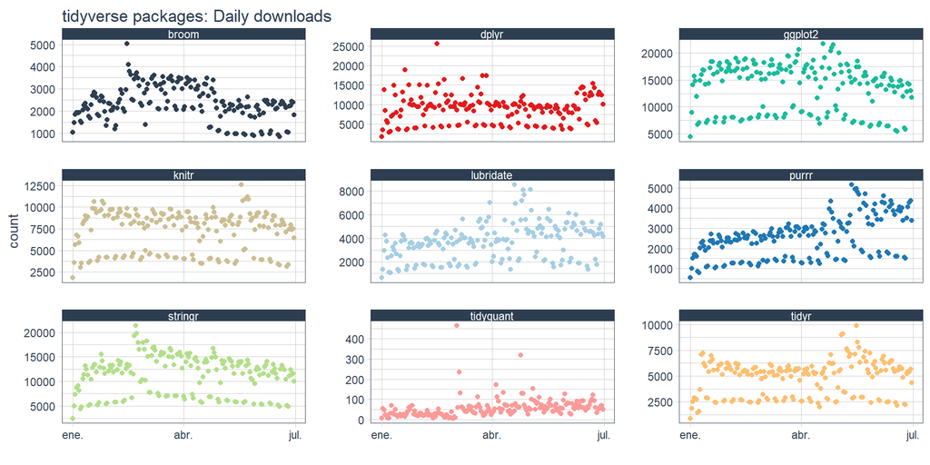

## Ejemplo: análisis de descargas de paquetes CRAN

- La forma de trabajar es muy similar a `xts`.
- Usamos las funciones `apply.___()` junto con `tq_transmute()` para calcular el promedio semanal de descargas.

```r
mean_tidyverse_downloads_w <- tidyverse_downloads %>%
    tq_transmute(
        select     = count,
        mutate_fun = apply.weekly,
        FUN        = mean,
        na.rm      = TRUE,
        col_rename = "mean_count"
    ); head(mean_tidyverse_downloads_w, 4)
```

```
## # A tibble: 4 x 3
## # Groups:   package [1]
##   package date       mean_count
##   <chr>   <date>          <dbl>
## 1 tidyr   2017-01-01       873
## 2 tidyr   2017-01-08      2263.
## 3 tidyr   2017-01-15      5129
## 4 tidyr   2017-01-22      5119.
```

## Ejemplo: análisis de descargas de paquetes CRAN

```r
mean_tidyverse_downloads_w %>%
    ggplot(aes(x = date, y = mean_count, color = package)) +
    geom_point() +
    geom_smooth(method = "loess") +
    labs(title = "tidyverse packages: Average daily downloads by week", x = "",
         y = "Mean Daily Downloads by Week") +
    facet_wrap(~ package, ncol = 3, scale = "free_y") +
    expand_limits(y = 0) +
    scale_color_tq() +
    theme_tq() +
    theme(legend.position="none")
```

## Ejemplo: análisis de descargas de paquetes CRAN

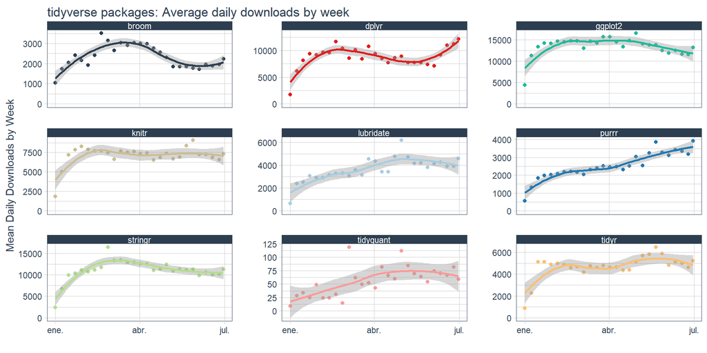

## Más ejercicios sobre este ejemplo

- Operaciones por periodos (parte I):
- https://www.business-science.io/timeseries-analysis/2017/07/02/tidy-timeseries-analysis.html.
- Funciones con ventanas temporales (parte II):
- http://www.business-science.io/timeseries-analysis/2017/07/23/tidy-timeseries-analysis-pt-2.html.
- Correlaciones con ventanas temporales (parte III):
- http://www.business-science.io/timeseries-analysis/2017/07/30/tidy-timeseries-analysis-pt-3.html.
- Retardos y autocorrelaciones (parte IV).
- http://www.business-science.io/timeseries-analysis/2017/08/30/tidy-timeseries-analysis-pt-4.html.

## Conclusiones

- `tsibble` y `tidyquant` son dos nuevos paquetes para procesado y análisis de series temporales en el contexto del entorno `tidyverse`.
- De momento, ambos han sido “reconocidos” como los paquetes de referencia para series temporales en este entorno.
  - Max Kuhn tiene planificado incluirlo dentro de la lista de paquetes que carga `tidymodels`, el metapaquete para unificar las diferentes herramientas para modelado de datos y análisis estadístico en `tidyverse`.
  - https://www.tidyverse.org/articles/2018/08/tidymodels-0-0-1/.
  - https://github.com/tidymodels/tidymodels.
- `tsibble` es más potente, ya que incluye soporte para definir *claves primarias*, que van a permitir cruzar y alinear datos de diferentes series temporales (análisis multivariante), para series jerárquicas y/o agrupadas.
- `tidyquant` es más sencillo, ya que opera directamente sobre objetos `tibble`, detectando la columna que contiene el índice temporal. Utiliza las mismas funciones que `xts`, `quantmod` y `PerformanceAnalytics`, añadiendo soporte para tidy data.

## Referencias

- Singer, J. D. & Willett, J. B. *Applied Longitudinal Data Analysis: Modeling Change and Event Occurrence*. Oxford University Press, 2003.
- William W. S. Wei. *Multivariate Time Series Analysis and Applications*. Wiley Series in Probability and Statistics, 2019.
- [Website tsibble](https://pkg.earo.me/tsibble/).
  - [Vignette: Introduction to tsibble](https://pkg.earo.me/tsibble/articles/intro-tsibble.html).
  - [Vignette: Window functions](https://pkg.earo.me/tsibble/articles/window.html).
- [Paquete tidyquant en CRAN](https://cran.r-project.org/web/packages/tidyquant/).
  - [Vignette: Introduction to tidyquant](https://cran.r-project.org/web/packages/tidyquant/vignettes/TQ00-introduction-to-tidyquant.html).
  - [Vignette: Core functions in tidyquant](https://cran.r-project.org/web/packages/tidyquant/vignettes/TQ01-core-functions-in-tidyquant.html).
  - [Vignette: Charting in tidyquant](https://cran.r-project.org/web/packages/tidyquant/vignettes/TQ04-charting-with-tidyquant.html).